# Risk Factor Analysis

## Outcome Variable

**Outcome Variable:** ever_stunted

## Predictor Variables

**Intervention Variable:** mbmi

**Adjustment Set:**

- arm
- W_mage
- meducyrs
- feducyrs
- W_nchldlt5
- brthmon
- W_parity
- delta_W_mage
- delta_meducyrs
- delta_feducyrs
- delta_W_nchldlt5
- delta_brthmon
- delta_W_parity

## Stratifying Variables

The analysis was stratified on these variable(s):

- agecat
- studyid
- country

## Data Summary

| agecat | studyid | country | mbmi | ever_stunted | n_cell | n |
| --- | --- | --- | --- | --- | --- | --- |
| 0-24 months | ki0047075b-MAL-ED | BANGLADESH | Normal weight | 0 | 89 | 254 |
| 0-24 months | ki0047075b-MAL-ED | BANGLADESH | Normal weight | 1 | 133 | 254 |
| 0-24 months | ki0047075b-MAL-ED | BANGLADESH | Underweight | 0 | 9 | 254 |
| 0-24 months | ki0047075b-MAL-ED | BANGLADESH | Underweight | 1 | 23 | 254 |
| 0-24 months | ki0047075b-MAL-ED | BRAZIL | Normal weight | 0 | 158 | 221 |
| 0-24 months | ki0047075b-MAL-ED | BRAZIL | Normal weight | 1 | 53 | 221 |
| 0-24 months | ki0047075b-MAL-ED | BRAZIL | Underweight | 0 | 6 | 221 |
| 0-24 months | ki0047075b-MAL-ED | BRAZIL | Underweight | 1 | 4 | 221 |
| 0-24 months | ki0047075b-MAL-ED | INDIA | Normal weight | 0 | 74 | 242 |
| 0-24 months | ki0047075b-MAL-ED | INDIA | Normal weight | 1 | 119 | 242 |
| 0-24 months | ki0047075b-MAL-ED | INDIA | Underweight | 0 | 19 | 242 |
| 0-24 months | ki0047075b-MAL-ED | INDIA | Underweight | 1 | 30 | 242 |
| 0-24 months | ki0047075b-MAL-ED | NEPAL | Normal weight | 0 | 155 | 238 |
| 0-24 months | ki0047075b-MAL-ED | NEPAL | Normal weight | 1 | 83 | 238 |
| 0-24 months | ki0047075b-MAL-ED | NEPAL | Underweight | 0 | 0 | 238 |
| 0-24 months | ki0047075b-MAL-ED | NEPAL | Underweight | 1 | 0 | 238 |
| 0-24 months | ki0047075b-MAL-ED | PERU | Normal weight | 0 | 102 | 290 |
| 0-24 months | ki0047075b-MAL-ED | PERU | Normal weight | 1 | 183 | 290 |
| 0-24 months | ki0047075b-MAL-ED | PERU | Underweight | 0 | 2 | 290 |
| 0-24 months | ki0047075b-MAL-ED | PERU | Underweight | 1 | 3 | 290 |
| 0-24 months | ki0047075b-MAL-ED | SOUTH AFRICA | Normal weight | 0 | 107 | 270 |
| 0-24 months | ki0047075b-MAL-ED | SOUTH AFRICA | Normal weight | 1 | 155 | 270 |
| 0-24 months | ki0047075b-MAL-ED | SOUTH AFRICA | Underweight | 0 | 1 | 270 |
| 0-24 months | ki0047075b-MAL-ED | SOUTH AFRICA | Underweight | 1 | 7 | 270 |
| 0-24 months | ki0047075b-MAL-ED | TANZANIA, UNITED REPUBLIC OF | Normal weight | 0 | 32 | 256 |
| 0-24 months | ki0047075b-MAL-ED | TANZANIA, UNITED REPUBLIC OF | Normal weight | 1 | 210 | 256 |
| 0-24 months | ki0047075b-MAL-ED | TANZANIA, UNITED REPUBLIC OF | Underweight | 0 | 3 | 256 |
| 0-24 months | ki0047075b-MAL-ED | TANZANIA, UNITED REPUBLIC OF | Underweight | 1 | 11 | 256 |
| 0-24 months | ki1000304b-SAS-CompFeed | INDIA | Normal weight | 0 | 353 | 1407 |
| 0-24 months | ki1000304b-SAS-CompFeed | INDIA | Normal weight | 1 | 675 | 1407 |

[output cut: 170 more lines]

The following strata were considered:

- agecat: 0-24 months, studyid: ki0047075b-MAL-ED, country: BANGLADESH
- agecat: 0-24 months, studyid: ki0047075b-MAL-ED, country: BRAZIL
- agecat: 0-24 months, studyid: ki0047075b-MAL-ED, country: INDIA
- agecat: 0-24 months, studyid: ki0047075b-MAL-ED, country: NEPAL
- agecat: 0-24 months, studyid: ki0047075b-MAL-ED, country: PERU
- agecat: 0-24 months, studyid: ki0047075b-MAL-ED, country: SOUTH AFRICA
- agecat: 0-24 months, studyid: ki0047075b-MAL-ED, country: TANZANIA, UNITED REPUBLIC OF
- agecat: 0-24 months, studyid: ki1000304b-SAS-CompFeed, country: INDIA
- agecat: 0-24 months, studyid: ki1017093-NIH-Birth, country: BANGLADESH
- agecat: 0-24 months, studyid: ki1017093b-PROVIDE, country: BANGLADESH
- agecat: 0-24 months, studyid: ki1017093c-NIH-Crypto, country: BANGLADESH
- agecat: 0-24 months, studyid: ki1066203-TanzaniaChild2, country: TANZANIA, UNITED REPUBLIC OF
- agecat: 0-24 months, studyid: ki1112895-iLiNS-Zinc, country: BURKINA FASO
- agecat: 0-24 months, studyid: ki1119695-PROBIT, country: BELARUS
- agecat: 0-24 months, studyid: ki1126311-ZVITAMBO, country: ZIMBABWE
- agecat: 0-24 months, studyid: ki1148112-LCNI-5, country: MALAWI
- agecat: 0-24 months, studyid: kiGH5241-JiVitA-3, country: BANGLADESH
- agecat: 0-6 months, studyid: ki0047075b-MAL-ED, country: BANGLADESH
- agecat: 0-6 months, studyid: ki0047075b-MAL-ED, country: BRAZIL
- agecat: 0-6 months, studyid: ki0047075b-MAL-ED, country: INDIA
- agecat: 0-6 months, studyid: ki0047075b-MAL-ED, country: NEPAL
- agecat: 0-6 months, studyid: ki0047075b-MAL-ED, country: PERU
- agecat: 0-6 months, studyid: ki0047075b-MAL-ED, country: SOUTH AFRICA
- agecat: 0-6 months, studyid: ki0047075b-MAL-ED, country: TANZANIA, UNITED REPUBLIC OF
- agecat: 0-6 months, studyid: ki1000304b-SAS-CompFeed, country: INDIA
- agecat: 0-6 months, studyid: ki1017093-NIH-Birth, country: BANGLADESH
- agecat: 0-6 months, studyid: ki1017093b-PROVIDE, country: BANGLADESH
- agecat: 0-6 months, studyid: ki1017093c-NIH-Crypto, country: BANGLADESH
- agecat: 0-6 months, studyid: ki1066203-TanzaniaChild2, country: TANZANIA, UNITED REPUBLIC OF
- agecat: 0-6 months, studyid: ki1119695-PROBIT, country: BELARUS
- agecat: 0-6 months, studyid: ki1126311-ZVITAMBO, country: ZIMBABWE
- agecat: 0-6 months, studyid: ki1148112-LCNI-5, country: MALAWI
- agecat: 0-6 months, studyid: kiGH5241-JiVitA-3, country: BANGLADESH
- agecat: 6-24 months, studyid: ki0047075b-MAL-ED, country: BANGLADESH
- agecat: 6-24 months, studyid: ki0047075b-MAL-ED, country: BRAZIL
- agecat: 6-24 months, studyid: ki0047075b-MAL-ED, country: INDIA
- agecat: 6-24 months, studyid: ki0047075b-MAL-ED, country: NEPAL
- agecat: 6-24 months, studyid: ki0047075b-MAL-ED, country: PERU
- agecat: 6-24 months, studyid: ki0047075b-MAL-ED, country: SOUTH AFRICA
- agecat: 6-24 months, studyid: ki0047075b-MAL-ED, country: TANZANIA, UNITED REPUBLIC OF
- agecat: 6-24 months, studyid: ki1000304b-SAS-CompFeed, country: INDIA
- agecat: 6-24 months, studyid: ki1017093-NIH-Birth, country: BANGLADESH
- agecat: 6-24 months, studyid: ki1017093b-PROVIDE, country: BANGLADESH
- agecat: 6-24 months, studyid: ki1017093c-NIH-Crypto, country: BANGLADESH
- agecat: 6-24 months, studyid: ki1066203-TanzaniaChild2, country: TANZANIA, UNITED REPUBLIC OF
- agecat: 6-24 months, studyid: ki1112895-iLiNS-Zinc, country: BURKINA FASO
- agecat: 6-24 months, studyid: ki1119695-PROBIT, country: BELARUS
- agecat: 6-24 months, studyid: ki1126311-ZVITAMBO, country: ZIMBABWE
- agecat: 6-24 months, studyid: ki1148112-LCNI-5, country: MALAWI
- agecat: 6-24 months, studyid: kiGH5241-JiVitA-3, country: BANGLADESH

### Dropped Strata

Some strata were dropped due to rare outcomes:

- agecat: 0-24 months, studyid: ki0047075b-MAL-ED, country: BRAZIL
- agecat: 0-24 months, studyid: ki0047075b-MAL-ED, country: NEPAL
- agecat: 0-24 months, studyid: ki0047075b-MAL-ED, country: PERU
- agecat: 0-24 months, studyid: ki0047075b-MAL-ED, country: SOUTH AFRICA
- agecat: 0-24 months, studyid: ki0047075b-MAL-ED, country: TANZANIA, UNITED REPUBLIC OF
- agecat: 0-6 months, studyid: ki0047075b-MAL-ED, country: BRAZIL
- agecat: 0-6 months, studyid: ki0047075b-MAL-ED, country: NEPAL
- agecat: 0-6 months, studyid: ki0047075b-MAL-ED, country: PERU
- agecat: 0-6 months, studyid: ki0047075b-MAL-ED, country: SOUTH AFRICA
- agecat: 6-24 months, studyid: ki0047075b-MAL-ED, country: BRAZIL
- agecat: 6-24 months, studyid: ki0047075b-MAL-ED, country: NEPAL
- agecat: 6-24 months, studyid: ki0047075b-MAL-ED, country: PERU
- agecat: 6-24 months, studyid: ki0047075b-MAL-ED, country: SOUTH AFRICA
- agecat: 6-24 months, studyid: ki0047075b-MAL-ED, country: TANZANIA, UNITED REPUBLIC OF

## Methods Detail

We’re interested in the causal parameters $E[Y_a]$ for all values of $a \in \mathcal{A}$. These parameters represent the mean outcome if, possibly contrary to fact, we intervened to set all units to have $A=a$. Under the randomization and positivity assumptions, these are identified by the statistical parameters $\psi_a=E_W[E_{Y|A,W}(Y|A=a,W)]$. In addition, we’re interested in the mean of $Y$, $E[Y]$ under no intervention (the observed mean). We will estimate these parameters by using SuperLearner to fit the relevant likelihood factors – $E_{Y|A,W}(Y|A=a,W)$ and $p(A=a|W)$, and then updating our likelihood fit using a joint TMLE.

For unadjusted analyses ($W=\{\}$), initial likelihoods were estimated using Lrnr_glm to estimate the simple $E(Y|A)$ and Lrnr_mean to estimate $p(A)$. For adjusted analyses, a small library containing Lrnr_glmnet, Lrnr_xgboost, and Lrnr_mean was used.

Having estimated these parameters, we will then use the delta method to estimate relative risks and attributable risks relative to a prespecified baseline level of $A$.

# Results Detail

## Results Plots

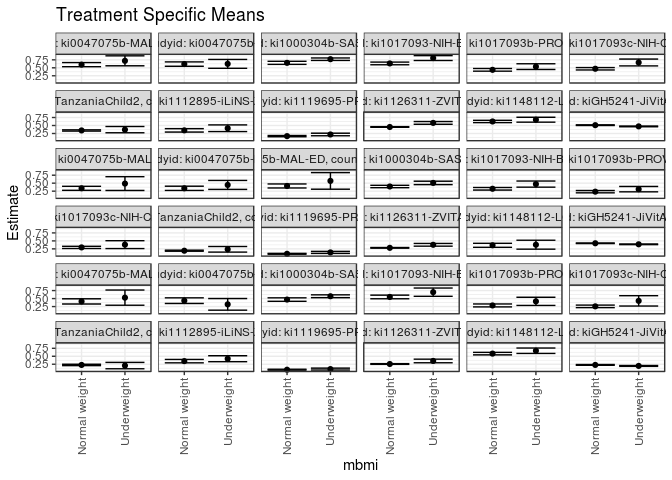

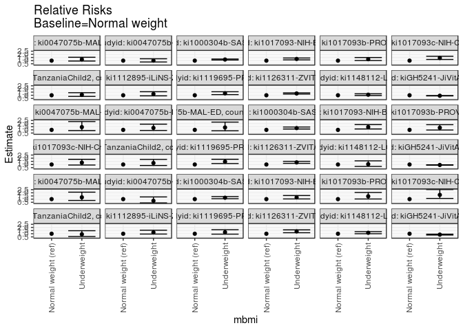

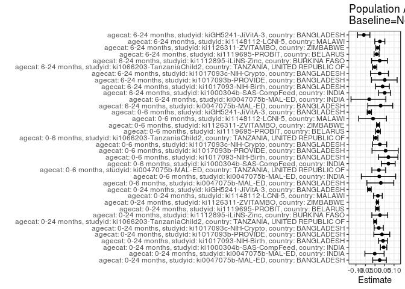

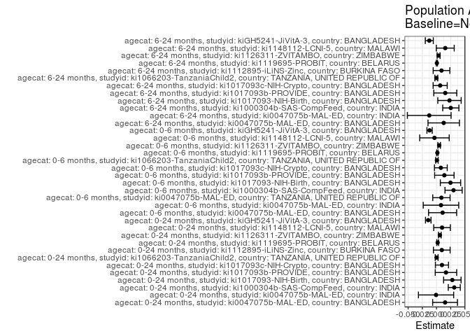

## Results Table

### Parameter: TSM

| agecat | studyid | country | intervention_level | baseline_level | estimate | ci_lower | ci_upper |
| --- | --- | --- | --- | --- | --- | --- | --- |
| 0-24 months | ki0047075b-MAL-ED | BANGLADESH | Normal weight | NA | 0.5990991 | 0.5345045 | 0.6636937 |
| 0-24 months | ki0047075b-MAL-ED | BANGLADESH | Underweight | NA | 0.7187500 | 0.5626637 | 0.8748363 |
| 0-24 months | ki0047075b-MAL-ED | INDIA | Normal weight | NA | 0.6165017 | 0.5476766 | 0.6853267 |
| 0-24 months | ki0047075b-MAL-ED | INDIA | Underweight | NA | 0.6231344 | 0.4843571 | 0.7619116 |
| 0-24 months | ki1000304b-SAS-CompFeed | INDIA | Normal weight | NA | 0.6552778 | 0.6069311 | 0.7036244 |
| 0-24 months | ki1000304b-SAS-CompFeed | INDIA | Underweight | NA | 0.7696526 | 0.7311026 | 0.8082026 |
| 0-24 months | ki1017093-NIH-Birth | BANGLADESH | Normal weight | NA | 0.6366548 | 0.5953885 | 0.6779211 |
| 0-24 months | ki1017093-NIH-Birth | BANGLADESH | Underweight | NA | 0.8050724 | 0.7284467 | 0.8816980 |
| 0-24 months | ki1017093b-PROVIDE | BANGLADESH | Normal weight | NA | 0.4362666 | 0.3941881 | 0.4783452 |
| 0-24 months | ki1017093b-PROVIDE | BANGLADESH | Underweight | NA | 0.5370039 | 0.4474681 | 0.6265396 |
| 0-24 months | ki1017093c-NIH-Crypto | BANGLADESH | Normal weight | NA | 0.4698523 | 0.4323944 | 0.5073101 |
| 0-24 months | ki1017093c-NIH-Crypto | BANGLADESH | Underweight | NA | 0.6661930 | 0.5591052 | 0.7732808 |
| 0-24 months | ki1066203-TanzaniaChild2 | TANZANIA, UNITED REPUBLIC OF | Normal weight | NA | 0.3451401 | 0.3255430 | 0.3647371 |
| 0-24 months | ki1066203-TanzaniaChild2 | TANZANIA, UNITED REPUBLIC OF | Underweight | NA | 0.3701362 | 0.2717848 | 0.4684876 |
| 0-24 months | ki1112895-iLiNS-Zinc | BURKINA FASO | Normal weight | NA | 0.3473746 | 0.2941294 | 0.4006198 |
| 0-24 months | ki1112895-iLiNS-Zinc | BURKINA FASO | Underweight | NA | 0.4138901 | 0.3092188 | 0.5185613 |
| 0-24 months | ki1119695-PROBIT | BELARUS | Normal weight | NA | 0.1672408 | 0.1480041 | 0.1864775 |
| 0-24 months | ki1119695-PROBIT | BELARUS | Underweight | NA | 0.2188331 | 0.1787594 | 0.2589068 |
| 0-24 months | ki1126311-ZVITAMBO | ZIMBABWE | Normal weight | NA | 0.4530361 | 0.4429135 | 0.4631587 |
| 0-24 months | ki1126311-ZVITAMBO | ZIMBABWE | Underweight | NA | 0.5810230 | 0.5383538 | 0.6236921 |
| 0-24 months | ki1148112-LCNI-5 | MALAWI | Normal weight | NA | 0.6258501 | 0.5897664 | 0.6619337 |
| 0-24 months | ki1148112-LCNI-5 | MALAWI | Underweight | NA | 0.6809644 | 0.6045033 | 0.7574254 |
| 0-24 months | kiGH5241-JiVitA-3 | BANGLADESH | Normal weight | NA | 0.5100625 | 0.5006851 | 0.5194399 |
| 0-24 months | kiGH5241-JiVitA-3 | BANGLADESH | Underweight | NA | 0.4719588 | 0.4610855 | 0.4828321 |
| 0-6 months | ki0047075b-MAL-ED | BANGLADESH | Normal weight | NA | 0.3396331 | 0.2765780 | 0.4026883 |
| 0-6 months | ki0047075b-MAL-ED | BANGLADESH | Underweight | NA | 0.4873701 | 0.2720647 | 0.7026756 |
| 0-6 months | ki0047075b-MAL-ED | INDIA | Normal weight | NA | 0.3392250 | 0.2726507 | 0.4057992 |
| 0-6 months | ki0047075b-MAL-ED | INDIA | Underweight | NA | 0.4455468 | 0.3054068 | 0.5856867 |
| 0-6 months | ki0047075b-MAL-ED | TANZANIA, UNITED REPUBLIC OF | Normal weight | NA | 0.4132231 | 0.3510620 | 0.4753843 |
| 0-6 months | ki0047075b-MAL-ED | TANZANIA, UNITED REPUBLIC OF | Underweight | NA | 0.5714286 | 0.3116959 | 0.8311612 |
| 0-6 months | ki1000304b-SAS-CompFeed | INDIA | Normal weight | NA | 0.3965824 | 0.3587352 | 0.4344297 |
| 0-6 months | ki1000304b-SAS-CompFeed | INDIA | Underweight | NA | 0.5091033 | 0.4558095 | 0.5623972 |
| 0-6 months | ki1017093-NIH-Birth | BANGLADESH | Normal weight | NA | 0.3251118 | 0.2848844 | 0.3653393 |
| 0-6 months | ki1017093-NIH-Birth | BANGLADESH | Underweight | NA | 0.4714345 | 0.3756903 | 0.5671787 |
| 0-6 months | ki1017093b-PROVIDE | BANGLADESH | Normal weight | NA | 0.2342917 | 0.1983127 | 0.2702707 |
| 0-6 months | ki1017093b-PROVIDE | BANGLADESH | Underweight | NA | 0.3130775 | 0.2288453 | 0.3973097 |
| 0-6 months | ki1017093c-NIH-Crypto | BANGLADESH | Normal weight | NA | 0.2956641 | 0.2614228 | 0.3299054 |
| 0-6 months | ki1017093c-NIH-Crypto | BANGLADESH | Underweight | NA | 0.3823468 | 0.2589683 | 0.5057254 |
| 0-6 months | ki1066203-TanzaniaChild2 | TANZANIA, UNITED REPUBLIC OF | Normal weight | NA | 0.1920243 | 0.1758027 | 0.2082459 |
| 0-6 months | ki1066203-TanzaniaChild2 | TANZANIA, UNITED REPUBLIC OF | Underweight | NA | 0.2368421 | 0.1492053 | 0.3244789 |
| 0-6 months | ki1119695-PROBIT | BELARUS | Normal weight | NA | 0.0954768 | 0.0822126 | 0.1087410 |
| 0-6 months | ki1119695-PROBIT | BELARUS | Underweight | NA | 0.1387753 | 0.1071581 | 0.1703924 |
| 0-6 months | ki1126311-ZVITAMBO | ZIMBABWE | Normal weight | NA | 0.2822519 | 0.2730938 | 0.2914100 |
| 0-6 months | ki1126311-ZVITAMBO | ZIMBABWE | Underweight | NA | 0.3775055 | 0.3343751 | 0.4206359 |
| 0-6 months | ki1148112-LCNI-5 | MALAWI | Normal weight | NA | 0.3615512 | 0.2984300 | 0.4246724 |
| 0-6 months | ki1148112-LCNI-5 | MALAWI | Underweight | NA | 0.3802374 | 0.2404318 | 0.5200429 |
| 0-6 months | kiGH5241-JiVitA-3 | BANGLADESH | Normal weight | NA | 0.4252297 | 0.4161927 | 0.4342668 |
| 0-6 months | kiGH5241-JiVitA-3 | BANGLADESH | Underweight | NA | 0.3932112 | 0.3829205 | 0.4035018 |
| 6-24 months | ki0047075b-MAL-ED | BANGLADESH | Normal weight | NA | 0.4113475 | 0.3298675 | 0.4928275 |
| 6-24 months | ki0047075b-MAL-ED | BANGLADESH | Underweight | NA | 0.5294118 | 0.2913884 | 0.7674352 |
| 6-24 months | ki0047075b-MAL-ED | INDIA | Normal weight | NA | 0.4349010 | 0.3469410 | 0.5228610 |
| 6-24 months | ki0047075b-MAL-ED | INDIA | Underweight | NA | 0.3193846 | 0.1376524 | 0.5011167 |
| 6-24 months | ki1000304b-SAS-CompFeed | INDIA | Normal weight | NA | 0.4687573 | 0.4148797 | 0.5226349 |
| 6-24 months | ki1000304b-SAS-CompFeed | INDIA | Underweight | NA | 0.5731446 | 0.5285430 | 0.6177463 |
| 6-24 months | ki1017093-NIH-Birth | BANGLADESH | Normal weight | NA | 0.5510359 | 0.4942707 | 0.6078011 |
| 6-24 months | ki1017093-NIH-Birth | BANGLADESH | Underweight | NA | 0.7005243 | 0.5714301 | 0.8296184 |
| 6-24 months | ki1017093b-PROVIDE | BANGLADESH | Normal weight | NA | 0.2849938 | 0.2392714 | 0.3307162 |
| 6-24 months | ki1017093b-PROVIDE | BANGLADESH | Underweight | NA | 0.4129206 | 0.2847968 | 0.5410443 |
| 6-24 months | ki1017093c-NIH-Crypto | BANGLADESH | Normal weight | NA | 0.2563894 | 0.2165687 | 0.2962101 |
| 6-24 months | ki1017093c-NIH-Crypto | BANGLADESH | Underweight | NA | 0.4284420 | 0.2663803 | 0.5905038 |
| 6-24 months | ki1066203-TanzaniaChild2 | TANZANIA, UNITED REPUBLIC OF | Normal weight | NA | 0.2283312 | 0.2071921 | 0.2494702 |
| 6-24 months | ki1066203-TanzaniaChild2 | TANZANIA, UNITED REPUBLIC OF | Underweight | NA | 0.2083333 | 0.1089524 | 0.3077142 |
| 6-24 months | ki1112895-iLiNS-Zinc | BURKINA FASO | Normal weight | NA | 0.3478523 | 0.2948453 | 0.4008594 |
| 6-24 months | ki1112895-iLiNS-Zinc | BURKINA FASO | Underweight | NA | 0.4231920 | 0.3295487 | 0.5168354 |
| 6-24 months | ki1119695-PROBIT | BELARUS | Normal weight | NA | 0.0794084 | 0.0650371 | 0.0937797 |
| 6-24 months | ki1119695-PROBIT | BELARUS | Underweight | NA | 0.0984806 | 0.0685331 | 0.1284280 |
| 6-24 months | ki1126311-ZVITAMBO | ZIMBABWE | Normal weight | NA | 0.2578199 | 0.2468923 | 0.2687475 |
| 6-24 months | ki1126311-ZVITAMBO | ZIMBABWE | Underweight | NA | 0.3534692 | 0.2971862 | 0.4097522 |
| 6-24 months | ki1148112-LCNI-5 | MALAWI | Normal weight | NA | 0.5829285 | 0.5435652 | 0.6222917 |
| 6-24 months | ki1148112-LCNI-5 | MALAWI | Underweight | NA | 0.6730377 | 0.5889780 | 0.7570974 |
| 6-24 months | kiGH5241-JiVitA-3 | BANGLADESH | Normal weight | NA | 0.2290395 | 0.2166917 | 0.2413874 |
| 6-24 months | kiGH5241-JiVitA-3 | BANGLADESH | Underweight | NA | 0.1978411 | 0.1845397 | 0.2111424 |

### Parameter: E(Y)

| agecat | studyid | country | intervention_level | baseline_level | estimate | ci_lower | ci_upper |
| --- | --- | --- | --- | --- | --- | --- | --- |
| 0-24 months | ki0047075b-MAL-ED | BANGLADESH | NA | NA | 0.6141732 | 0.5541901 | 0.6741564 |
| 0-24 months | ki0047075b-MAL-ED | INDIA | NA | NA | 0.6157025 | 0.5542897 | 0.6771153 |
| 0-24 months | ki1000304b-SAS-CompFeed | INDIA | NA | NA | 0.6865672 | 0.6433613 | 0.7297731 |
| 0-24 months | ki1017093-NIH-Birth | BANGLADESH | NA | NA | 0.6645469 | 0.6276196 | 0.7014742 |
| 0-24 months | ki1017093b-PROVIDE | BANGLADESH | NA | NA | 0.4529148 | 0.4151667 | 0.4906629 |
| 0-24 months | ki1017093c-NIH-Crypto | BANGLADESH | NA | NA | 0.4794702 | 0.4438115 | 0.5151289 |
| 0-24 months | ki1066203-TanzaniaChild2 | TANZANIA, UNITED REPUBLIC OF | NA | NA | 0.3454158 | 0.3261661 | 0.3646654 |
| 0-24 months | ki1112895-iLiNS-Zinc | BURKINA FASO | NA | NA | 0.3566542 | 0.3069876 | 0.4063208 |
| 0-24 months | ki1119695-PROBIT | BELARUS | NA | NA | 0.1692890 | 0.1503168 | 0.1882613 |
| 0-24 months | ki1126311-ZVITAMBO | ZIMBABWE | NA | NA | 0.4589062 | 0.4490494 | 0.4687630 |
| 0-24 months | ki1148112-LCNI-5 | MALAWI | NA | NA | 0.6356033 | 0.6029802 | 0.6682264 |
| 0-24 months | kiGH5241-JiVitA-3 | BANGLADESH | NA | NA | 0.4955174 | 0.4876719 | 0.5033630 |
| 0-6 months | ki0047075b-MAL-ED | BANGLADESH | NA | NA | 0.3503937 | 0.2916054 | 0.4091820 |
| 0-6 months | ki0047075b-MAL-ED | INDIA | NA | NA | 0.3471074 | 0.2870050 | 0.4072099 |
| 0-6 months | ki0047075b-MAL-ED | TANZANIA, UNITED REPUBLIC OF | NA | NA | 0.4218750 | 0.3612599 | 0.4824901 |
| 0-6 months | ki1000304b-SAS-CompFeed | INDIA | NA | NA | 0.4266382 | 0.3925570 | 0.4607194 |
| 0-6 months | ki1017093-NIH-Birth | BANGLADESH | NA | NA | 0.3497615 | 0.3124631 | 0.3870600 |
| 0-6 months | ki1017093b-PROVIDE | BANGLADESH | NA | NA | 0.2481315 | 0.2153770 | 0.2808861 |
| 0-6 months | ki1017093c-NIH-Crypto | BANGLADESH | NA | NA | 0.3033113 | 0.2704998 | 0.3361228 |
| 0-6 months | ki1066203-TanzaniaChild2 | TANZANIA, UNITED REPUBLIC OF | NA | NA | 0.1927505 | 0.1767818 | 0.2087193 |
| 0-6 months | ki1119695-PROBIT | BELARUS | NA | NA | 0.0970280 | 0.0839943 | 0.1100616 |
| 0-6 months | ki1126311-ZVITAMBO | ZIMBABWE | NA | NA | 0.2869086 | 0.2779566 | 0.2958607 |
| 0-6 months | ki1148112-LCNI-5 | MALAWI | NA | NA | 0.3579336 | 0.3007518 | 0.4151153 |
| 0-6 months | kiGH5241-JiVitA-3 | BANGLADESH | NA | NA | 0.4130330 | 0.4055721 | 0.4204940 |
| 6-24 months | ki0047075b-MAL-ED | BANGLADESH | NA | NA | 0.4240506 | 0.3467471 | 0.5013542 |
| 6-24 months | ki0047075b-MAL-ED | INDIA | NA | NA | 0.4220779 | 0.3438191 | 0.5003367 |
| 6-24 months | ki1000304b-SAS-CompFeed | INDIA | NA | NA | 0.4939435 | 0.4498186 | 0.5380683 |
| 6-24 months | ki1017093-NIH-Birth | BANGLADESH | NA | NA | 0.5739130 | 0.5216565 | 0.6261696 |
| 6-24 months | ki1017093b-PROVIDE | BANGLADESH | NA | NA | 0.3004386 | 0.2583143 | 0.3425629 |
| 6-24 months | ki1017093c-NIH-Crypto | BANGLADESH | NA | NA | 0.2628458 | 0.2244546 | 0.3012371 |
| 6-24 months | ki1066203-TanzaniaChild2 | TANZANIA, UNITED REPUBLIC OF | NA | NA | 0.2280255 | 0.2072654 | 0.2487856 |
| 6-24 months | ki1112895-iLiNS-Zinc | BURKINA FASO | NA | NA | 0.3566542 | 0.3069876 | 0.4063208 |
| 6-24 months | ki1119695-PROBIT | BELARUS | NA | NA | 0.0800775 | 0.0658478 | 0.0943072 |
| 6-24 months | ki1126311-ZVITAMBO | ZIMBABWE | NA | NA | 0.2615147 | 0.2508057 | 0.2722237 |
| 6-24 months | ki1148112-LCNI-5 | MALAWI | NA | NA | 0.5983494 | 0.5626894 | 0.6340094 |
| 6-24 months | kiGH5241-JiVitA-3 | BANGLADESH | NA | NA | 0.2163480 | 0.2069669 | 0.2257290 |

### Parameter: RR

| agecat | studyid | country | intervention_level | baseline_level | estimate | ci_lower | ci_upper |
| --- | --- | --- | --- | --- | --- | --- | --- |
| 0-24 months | ki0047075b-MAL-ED | BANGLADESH | Normal weight | Normal weight | 1.0000000 | 1.0000000 | 1.0000000 |
| 0-24 months | ki0047075b-MAL-ED | BANGLADESH | Underweight | Normal weight | 1.1997180 | 0.9414164 | 1.5288914 |
| 0-24 months | ki0047075b-MAL-ED | INDIA | Normal weight | Normal weight | 1.0000000 | 1.0000000 | 1.0000000 |
| 0-24 months | ki0047075b-MAL-ED | INDIA | Underweight | Normal weight | 1.0107586 | 0.7873187 | 1.2976104 |
| 0-24 months | ki1000304b-SAS-CompFeed | INDIA | Normal weight | Normal weight | 1.0000000 | 1.0000000 | 1.0000000 |
| 0-24 months | ki1000304b-SAS-CompFeed | INDIA | Underweight | Normal weight | 1.1745440 | 1.1006044 | 1.2534510 |
| 0-24 months | ki1017093-NIH-Birth | BANGLADESH | Normal weight | Normal weight | 1.0000000 | 1.0000000 | 1.0000000 |
| 0-24 months | ki1017093-NIH-Birth | BANGLADESH | Underweight | Normal weight | 1.2645352 | 1.1271139 | 1.4187113 |
| 0-24 months | ki1017093b-PROVIDE | BANGLADESH | Normal weight | Normal weight | 1.0000000 | 1.0000000 | 1.0000000 |
| 0-24 months | ki1017093b-PROVIDE | BANGLADESH | Underweight | Normal weight | 1.2309075 | 1.0152628 | 1.4923557 |
| 0-24 months | ki1017093c-NIH-Crypto | BANGLADESH | Normal weight | Normal weight | 1.0000000 | 1.0000000 | 1.0000000 |
| 0-24 months | ki1017093c-NIH-Crypto | BANGLADESH | Underweight | Normal weight | 1.4178776 | 1.1848640 | 1.6967153 |
| 0-24 months | ki1066203-TanzaniaChild2 | TANZANIA, UNITED REPUBLIC OF | Normal weight | Normal weight | 1.0000000 | 1.0000000 | 1.0000000 |
| 0-24 months | ki1066203-TanzaniaChild2 | TANZANIA, UNITED REPUBLIC OF | Underweight | Normal weight | 1.0724232 | 0.8172699 | 1.4072357 |
| 0-24 months | ki1112895-iLiNS-Zinc | BURKINA FASO | Normal weight | Normal weight | 1.0000000 | 1.0000000 | 1.0000000 |
| 0-24 months | ki1112895-iLiNS-Zinc | BURKINA FASO | Underweight | Normal weight | 1.1914805 | 0.9088588 | 1.5619871 |
| 0-24 months | ki1119695-PROBIT | BELARUS | Normal weight | Normal weight | 1.0000000 | 1.0000000 | 1.0000000 |
| 0-24 months | ki1119695-PROBIT | BELARUS | Underweight | Normal weight | 1.3084907 | 1.0994989 | 1.5572076 |
| 0-24 months | ki1126311-ZVITAMBO | ZIMBABWE | Normal weight | Normal weight | 1.0000000 | 1.0000000 | 1.0000000 |
| 0-24 months | ki1126311-ZVITAMBO | ZIMBABWE | Underweight | Normal weight | 1.2825092 | 1.1877295 | 1.3848521 |
| 0-24 months | ki1148112-LCNI-5 | MALAWI | Normal weight | Normal weight | 1.0000000 | 1.0000000 | 1.0000000 |
| 0-24 months | ki1148112-LCNI-5 | MALAWI | Underweight | Normal weight | 1.0880631 | 0.9589798 | 1.2345216 |
| 0-24 months | kiGH5241-JiVitA-3 | BANGLADESH | Normal weight | Normal weight | 1.0000000 | 1.0000000 | 1.0000000 |
| 0-24 months | kiGH5241-JiVitA-3 | BANGLADESH | Underweight | Normal weight | 0.9252959 | 0.9015550 | 0.9496620 |
| 0-6 months | ki0047075b-MAL-ED | BANGLADESH | Normal weight | Normal weight | 1.0000000 | 1.0000000 | 1.0000000 |
| 0-6 months | ki0047075b-MAL-ED | BANGLADESH | Underweight | Normal weight | 1.4349900 | 0.8899433 | 2.3138510 |
| 0-6 months | ki0047075b-MAL-ED | INDIA | Normal weight | Normal weight | 1.0000000 | 1.0000000 | 1.0000000 |
| 0-6 months | ki0047075b-MAL-ED | INDIA | Underweight | Normal weight | 1.3134256 | 0.9055153 | 1.9050888 |
| 0-6 months | ki0047075b-MAL-ED | TANZANIA, UNITED REPUBLIC OF | Normal weight | Normal weight | 1.0000000 | 1.0000000 | 1.0000000 |
| 0-6 months | ki0047075b-MAL-ED | TANZANIA, UNITED REPUBLIC OF | Underweight | Normal weight | 1.3828571 | 0.8567351 | 2.2320714 |
| 0-6 months | ki1000304b-SAS-CompFeed | INDIA | Normal weight | Normal weight | 1.0000000 | 1.0000000 | 1.0000000 |
| 0-6 months | ki1000304b-SAS-CompFeed | INDIA | Underweight | Normal weight | 1.2837265 | 1.1355740 | 1.4512076 |
| 0-6 months | ki1017093-NIH-Birth | BANGLADESH | Normal weight | Normal weight | 1.0000000 | 1.0000000 | 1.0000000 |
| 0-6 months | ki1017093-NIH-Birth | BANGLADESH | Underweight | Normal weight | 1.4500686 | 1.1430689 | 1.8395209 |
| 0-6 months | ki1017093b-PROVIDE | BANGLADESH | Normal weight | Normal weight | 1.0000000 | 1.0000000 | 1.0000000 |
| 0-6 months | ki1017093b-PROVIDE | BANGLADESH | Underweight | Normal weight | 1.3362723 | 0.9801865 | 1.8217183 |
| 0-6 months | ki1017093c-NIH-Crypto | BANGLADESH | Normal weight | Normal weight | 1.0000000 | 1.0000000 | 1.0000000 |
| 0-6 months | ki1017093c-NIH-Crypto | BANGLADESH | Underweight | Normal weight | 1.2931798 | 0.9177617 | 1.8221657 |
| 0-6 months | ki1066203-TanzaniaChild2 | TANZANIA, UNITED REPUBLIC OF | Normal weight | Normal weight | 1.0000000 | 1.0000000 | 1.0000000 |
| 0-6 months | ki1066203-TanzaniaChild2 | TANZANIA, UNITED REPUBLIC OF | Underweight | Normal weight | 1.2333967 | 0.8438583 | 1.8027521 |
| 0-6 months | ki1119695-PROBIT | BELARUS | Normal weight | Normal weight | 1.0000000 | 1.0000000 | 1.0000000 |
| 0-6 months | ki1119695-PROBIT | BELARUS | Underweight | Normal weight | 1.4534969 | 1.1546959 | 1.8296188 |
| 0-6 months | ki1126311-ZVITAMBO | ZIMBABWE | Normal weight | Normal weight | 1.0000000 | 1.0000000 | 1.0000000 |
| 0-6 months | ki1126311-ZVITAMBO | ZIMBABWE | Underweight | Normal weight | 1.3374772 | 1.1876957 | 1.5061477 |
| 0-6 months | ki1148112-LCNI-5 | MALAWI | Normal weight | Normal weight | 1.0000000 | 1.0000000 | 1.0000000 |
| 0-6 months | ki1148112-LCNI-5 | MALAWI | Underweight | Normal weight | 1.0516834 | 0.6999208 | 1.5802331 |
| 0-6 months | kiGH5241-JiVitA-3 | BANGLADESH | Normal weight | Normal weight | 1.0000000 | 1.0000000 | 1.0000000 |
| 0-6 months | kiGH5241-JiVitA-3 | BANGLADESH | Underweight | Normal weight | 0.9247029 | 0.8972656 | 0.9529793 |
| 6-24 months | ki0047075b-MAL-ED | BANGLADESH | Normal weight | Normal weight | 1.0000000 | 1.0000000 | 1.0000000 |
| 6-24 months | ki0047075b-MAL-ED | BANGLADESH | Underweight | Normal weight | 1.2870183 | 0.7874368 | 2.1035542 |
| 6-24 months | ki0047075b-MAL-ED | INDIA | Normal weight | Normal weight | 1.0000000 | 1.0000000 | 1.0000000 |
| 6-24 months | ki0047075b-MAL-ED | INDIA | Underweight | Normal weight | 0.7343845 | 0.4003279 | 1.3471973 |
| 6-24 months | ki1000304b-SAS-CompFeed | INDIA | Normal weight | Normal weight | 1.0000000 | 1.0000000 | 1.0000000 |
| 6-24 months | ki1000304b-SAS-CompFeed | INDIA | Underweight | Normal weight | 1.2226895 | 1.0628192 | 1.4066077 |
| 6-24 months | ki1017093-NIH-Birth | BANGLADESH | Normal weight | Normal weight | 1.0000000 | 1.0000000 | 1.0000000 |
| 6-24 months | ki1017093-NIH-Birth | BANGLADESH | Underweight | Normal weight | 1.2712861 | 1.0293955 | 1.5700169 |
| 6-24 months | ki1017093b-PROVIDE | BANGLADESH | Normal weight | Normal weight | 1.0000000 | 1.0000000 | 1.0000000 |
| 6-24 months | ki1017093b-PROVIDE | BANGLADESH | Underweight | Normal weight | 1.4488758 | 1.0215865 | 2.0548833 |
| 6-24 months | ki1017093c-NIH-Crypto | BANGLADESH | Normal weight | Normal weight | 1.0000000 | 1.0000000 | 1.0000000 |
| 6-24 months | ki1017093c-NIH-Crypto | BANGLADESH | Underweight | Normal weight | 1.6710596 | 1.1099617 | 2.5157987 |
| 6-24 months | ki1066203-TanzaniaChild2 | TANZANIA, UNITED REPUBLIC OF | Normal weight | Normal weight | 1.0000000 | 1.0000000 | 1.0000000 |
| 6-24 months | ki1066203-TanzaniaChild2 | TANZANIA, UNITED REPUBLIC OF | Underweight | Normal weight | 0.9124174 | 0.5612510 | 1.4833032 |
| 6-24 months | ki1112895-iLiNS-Zinc | BURKINA FASO | Normal weight | Normal weight | 1.0000000 | 1.0000000 | 1.0000000 |
| 6-24 months | ki1112895-iLiNS-Zinc | BURKINA FASO | Underweight | Normal weight | 1.2165853 | 0.9528972 | 1.5532417 |
| 6-24 months | ki1119695-PROBIT | BELARUS | Normal weight | Normal weight | 1.0000000 | 1.0000000 | 1.0000000 |
| 6-24 months | ki1119695-PROBIT | BELARUS | Underweight | Normal weight | 1.2401781 | 0.9376693 | 1.6402817 |
| 6-24 months | ki1126311-ZVITAMBO | ZIMBABWE | Normal weight | Normal weight | 1.0000000 | 1.0000000 | 1.0000000 |
| 6-24 months | ki1126311-ZVITAMBO | ZIMBABWE | Underweight | Normal weight | 1.3709928 | 1.1626991 | 1.6166015 |
| 6-24 months | ki1148112-LCNI-5 | MALAWI | Normal weight | Normal weight | 1.0000000 | 1.0000000 | 1.0000000 |
| 6-24 months | ki1148112-LCNI-5 | MALAWI | Underweight | Normal weight | 1.1545803 | 1.0017350 | 1.3307468 |
| 6-24 months | kiGH5241-JiVitA-3 | BANGLADESH | Normal weight | Normal weight | 1.0000000 | 1.0000000 | 1.0000000 |
| 6-24 months | kiGH5241-JiVitA-3 | BANGLADESH | Underweight | Normal weight | 0.8637857 | 0.7946048 | 0.9389897 |

### Parameter: PAR

| agecat | studyid | country | intervention_level | baseline_level | estimate | ci_lower | ci_upper |
| --- | --- | --- | --- | --- | --- | --- | --- |
| 0-24 months | ki0047075b-MAL-ED | BANGLADESH | Normal weight | NA | 0.0150741 | -0.0067628 | 0.0369110 |
| 0-24 months | ki0047075b-MAL-ED | INDIA | Normal weight | NA | -0.0007992 | -0.0318240 | 0.0302256 |
| 0-24 months | ki1000304b-SAS-CompFeed | INDIA | Normal weight | NA | 0.0312894 | 0.0207030 | 0.0418758 |
| 0-24 months | ki1017093-NIH-Birth | BANGLADESH | Normal weight | NA | 0.0278921 | 0.0125295 | 0.0432547 |
| 0-24 months | ki1017093b-PROVIDE | BANGLADESH | Normal weight | NA | 0.0166482 | -0.0022544 | 0.0355507 |
| 0-24 months | ki1017093c-NIH-Crypto | BANGLADESH | Normal weight | NA | 0.0096179 | -0.0019412 | 0.0211771 |
| 0-24 months | ki1066203-TanzaniaChild2 | TANZANIA, UNITED REPUBLIC OF | Normal weight | NA | 0.0002757 | -0.0022490 | 0.0028004 |
| 0-24 months | ki1112895-iLiNS-Zinc | BURKINA FASO | Normal weight | NA | 0.0092796 | -0.0054074 | 0.0239667 |
| 0-24 months | ki1119695-PROBIT | BELARUS | Normal weight | NA | 0.0020482 | 0.0005298 | 0.0035666 |
| 0-24 months | ki1126311-ZVITAMBO | ZIMBABWE | Normal weight | NA | 0.0058701 | 0.0034997 | 0.0082405 |
| 0-24 months | ki1148112-LCNI-5 | MALAWI | Normal weight | NA | 0.0097533 | -0.0049147 | 0.0244212 |
| 0-24 months | kiGH5241-JiVitA-3 | BANGLADESH | Normal weight | NA | -0.0145451 | -0.0193971 | -0.0096931 |
| 0-6 months | ki0047075b-MAL-ED | BANGLADESH | Normal weight | NA | 0.0107606 | -0.0139745 | 0.0354957 |
| 0-6 months | ki0047075b-MAL-ED | INDIA | Normal weight | NA | 0.0078825 | -0.0234107 | 0.0391757 |
| 0-6 months | ki0047075b-MAL-ED | TANZANIA, UNITED REPUBLIC OF | Normal weight | NA | 0.0086519 | -0.0066061 | 0.0239098 |
| 0-6 months | ki1000304b-SAS-CompFeed | INDIA | Normal weight | NA | 0.0300558 | 0.0149236 | 0.0451880 |
| 0-6 months | ki1017093-NIH-Birth | BANGLADESH | Normal weight | NA | 0.0246497 | 0.0067191 | 0.0425803 |
| 0-6 months | ki1017093b-PROVIDE | BANGLADESH | Normal weight | NA | 0.0138398 | -0.0032448 | 0.0309245 |
| 0-6 months | ki1017093c-NIH-Crypto | BANGLADESH | Normal weight | NA | 0.0076472 | -0.0036023 | 0.0188967 |
| 0-6 months | ki1066203-TanzaniaChild2 | TANZANIA, UNITED REPUBLIC OF | Normal weight | NA | 0.0007263 | -0.0015136 | 0.0029661 |
| 0-6 months | ki1119695-PROBIT | BELARUS | Normal weight | NA | 0.0015512 | 0.0003723 | 0.0027300 |
| 0-6 months | ki1126311-ZVITAMBO | ZIMBABWE | Normal weight | NA | 0.0046567 | 0.0023685 | 0.0069449 |
| 0-6 months | ki1148112-LCNI-5 | MALAWI | Normal weight | NA | -0.0036176 | -0.0296217 | 0.0223865 |
| 0-6 months | kiGH5241-JiVitA-3 | BANGLADESH | Normal weight | NA | -0.0121967 | -0.0168704 | -0.0075230 |
| 6-24 months | ki0047075b-MAL-ED | BANGLADESH | Normal weight | NA | 0.0127031 | -0.0149643 | 0.0403705 |
| 6-24 months | ki0047075b-MAL-ED | INDIA | Normal weight | NA | -0.0128231 | -0.0513386 | 0.0256924 |
| 6-24 months | ki1000304b-SAS-CompFeed | INDIA | Normal weight | NA | 0.0251862 | 0.0109376 | 0.0394347 |
| 6-24 months | ki1017093-NIH-Birth | BANGLADESH | Normal weight | NA | 0.0228771 | 0.0022819 | 0.0434724 |
| 6-24 months | ki1017093b-PROVIDE | BANGLADESH | Normal weight | NA | 0.0154448 | -0.0047831 | 0.0356727 |
| 6-24 months | ki1017093c-NIH-Crypto | BANGLADESH | Normal weight | NA | 0.0064564 | -0.0059476 | 0.0188604 |
| 6-24 months | ki1066203-TanzaniaChild2 | TANZANIA, UNITED REPUBLIC OF | Normal weight | NA | -0.0003057 | -0.0028487 | 0.0022373 |
| 6-24 months | ki1112895-iLiNS-Zinc | BURKINA FASO | Normal weight | NA | 0.0088019 | -0.0058718 | 0.0234755 |
| 6-24 months | ki1119695-PROBIT | BELARUS | Normal weight | NA | 0.0006691 | -0.0003708 | 0.0017090 |
| 6-24 months | ki1126311-ZVITAMBO | ZIMBABWE | Normal weight | NA | 0.0036948 | 0.0011050 | 0.0062846 |
| 6-24 months | ki1148112-LCNI-5 | MALAWI | Normal weight | NA | 0.0154209 | -0.0003513 | 0.0311932 |
| 6-24 months | kiGH5241-JiVitA-3 | BANGLADESH | Normal weight | NA | -0.0126915 | -0.0197431 | -0.0056400 |

### Parameter: PAF

| agecat | studyid | country | intervention_level | baseline_level | estimate | ci_lower | ci_upper |
| --- | --- | --- | --- | --- | --- | --- | --- |
| 0-24 months | ki0047075b-MAL-ED | BANGLADESH | Normal weight | NA | 0.0245438 | -0.0118432 | 0.0596222 |
| 0-24 months | ki0047075b-MAL-ED | INDIA | Normal weight | NA | -0.0012980 | -0.0529767 | 0.0478444 |
| 0-24 months | ki1000304b-SAS-CompFeed | INDIA | Normal weight | NA | 0.0455737 | 0.0286733 | 0.0621801 |
| 0-24 months | ki1017093-NIH-Birth | BANGLADESH | Normal weight | NA | 0.0419716 | 0.0182373 | 0.0651321 |
| 0-24 months | ki1017093b-PROVIDE | BANGLADESH | Normal weight | NA | 0.0367578 | -0.0059862 | 0.0776857 |
| 0-24 months | ki1017093c-NIH-Crypto | BANGLADESH | Normal weight | NA | 0.0200595 | -0.0043911 | 0.0439150 |
| 0-24 months | ki1066203-TanzaniaChild2 | TANZANIA, UNITED REPUBLIC OF | Normal weight | NA | 0.0007982 | -0.0065412 | 0.0080841 |
| 0-24 months | ki1112895-iLiNS-Zinc | BURKINA FASO | Normal weight | NA | 0.0260186 | -0.0166025 | 0.0668527 |
| 0-24 months | ki1119695-PROBIT | BELARUS | Normal weight | NA | 0.0120988 | 0.0028046 | 0.0213065 |
| 0-24 months | ki1126311-ZVITAMBO | ZIMBABWE | Normal weight | NA | 0.0127915 | 0.0076071 | 0.0179488 |
| 0-24 months | ki1148112-LCNI-5 | MALAWI | Normal weight | NA | 0.0153449 | -0.0080376 | 0.0381851 |
| 0-24 months | kiGH5241-JiVitA-3 | BANGLADESH | Normal weight | NA | -0.0293534 | -0.0391855 | -0.0196143 |
| 0-6 months | ki0047075b-MAL-ED | BANGLADESH | Normal weight | NA | 0.0307100 | -0.0425436 | 0.0988164 |
| 0-6 months | ki0047075b-MAL-ED | INDIA | Normal weight | NA | 0.0227091 | -0.0716455 | 0.1087560 |
| 0-6 months | ki0047075b-MAL-ED | TANZANIA, UNITED REPUBLIC OF | Normal weight | NA | 0.0205081 | -0.0163884 | 0.0560652 |
| 0-6 months | ki1000304b-SAS-CompFeed | INDIA | Normal weight | NA | 0.0704479 | 0.0335990 | 0.1058917 |
| 0-6 months | ki1017093-NIH-Birth | BANGLADESH | Normal weight | NA | 0.0704757 | 0.0177490 | 0.1203720 |
| 0-6 months | ki1017093b-PROVIDE | BANGLADESH | Normal weight | NA | 0.0557762 | -0.0155757 | 0.1221151 |
| 0-6 months | ki1017093c-NIH-Crypto | BANGLADESH | Normal weight | NA | 0.0252123 | -0.0125777 | 0.0615920 |
| 0-6 months | ki1066203-TanzaniaChild2 | TANZANIA, UNITED REPUBLIC OF | Normal weight | NA | 0.0037679 | -0.0079388 | 0.0153386 |
| 0-6 months | ki1119695-PROBIT | BELARUS | Normal weight | NA | 0.0159867 | 0.0032499 | 0.0285608 |
| 0-6 months | ki1126311-ZVITAMBO | ZIMBABWE | Normal weight | NA | 0.0162306 | 0.0082255 | 0.0241712 |
| 0-6 months | ki1148112-LCNI-5 | MALAWI | Normal weight | NA | -0.0101069 | -0.0854309 | 0.0599898 |
| 0-6 months | kiGH5241-JiVitA-3 | BANGLADESH | Normal weight | NA | -0.0295296 | -0.0408881 | -0.0182949 |
| 6-24 months | ki0047075b-MAL-ED | BANGLADESH | Normal weight | NA | 0.0299566 | -0.0376377 | 0.0931477 |
| 6-24 months | ki0047075b-MAL-ED | INDIA | Normal weight | NA | -0.0303808 | -0.1258538 | 0.0569960 |
| 6-24 months | ki1000304b-SAS-CompFeed | INDIA | Normal weight | NA | 0.0509900 | 0.0186682 | 0.0822472 |
| 6-24 months | ki1017093-NIH-Birth | BANGLADESH | Normal weight | NA | 0.0398617 | 0.0029897 | 0.0753700 |
| 6-24 months | ki1017093b-PROVIDE | BANGLADESH | Normal weight | NA | 0.0514076 | -0.0183587 | 0.1163943 |
| 6-24 months | ki1017093c-NIH-Crypto | BANGLADESH | Normal weight | NA | 0.0245635 | -0.0237648 | 0.0706104 |
| 6-24 months | ki1066203-TanzaniaChild2 | TANZANIA, UNITED REPUBLIC OF | Normal weight | NA | -0.0013406 | -0.0125449 | 0.0097397 |
| 6-24 months | ki1112895-iLiNS-Zinc | BURKINA FASO | Normal weight | NA | 0.0246790 | -0.0178048 | 0.0653896 |
| 6-24 months | ki1119695-PROBIT | BELARUS | Normal weight | NA | 0.0083557 | -0.0049508 | 0.0214859 |
| 6-24 months | ki1126311-ZVITAMBO | ZIMBABWE | Normal weight | NA | 0.0141284 | 0.0041793 | 0.0239781 |
| 6-24 months | ki1148112-LCNI-5 | MALAWI | Normal weight | NA | 0.0257724 | -0.0010336 | 0.0518607 |
| 6-24 months | kiGH5241-JiVitA-3 | BANGLADESH | Normal weight | NA | -0.0586627 | -0.0915725 | -0.0267450 |